# lab_7 script

Deanna Strayer, Alex Newson, Sabreen NoorAli, Tony Daza, Seulbi Lee

11/2/2022

```
## here() starts at /Users/sabreennoorali/Desktop/lab_7
##
##
##
##
```

#Question 3:  
**Table of Summary Statistics Examining Math and Reading scores by sex and Free/reduced Price Lunch Status**

[output not shown]

```
## # A tibble: 4 × 6
## # Groups:   sex [2]
##   sex   frl   math_mean math_sd rdg_mean rdg_sd
##   <chr> <chr>     <dbl>   <dbl>    <dbl>  <dbl>
## 1 boy   no         493.    46.3     441.   32.3
## 2 boy   yes        470.    46.1     425.   26.6
## 3 girl  no         501.    46.0     449.   34.5
## 4 girl  yes        478.    46.3     431.   27.4
```

The table above shows the mean and standard deviation of math and reading scores for boys and girls mediated by free and reduced price lunch status.

Girls without Free/Reduced price lunch had the highest math and reading scores while boys without Free/Reduced price lunch scored higher than both boys and girls *with* Free/Reduced Price lunch.

The mean math score for boys *with* Free/Reduced price lunch was **469.87** compared to boys with *paid lunch* who had an average math score of **492.85**

The trend continued for girl where the mean math score for girls *with* Free/Reduced price lunch was **477.51** compared to girls with *paid lunch* who had an average math score of **501.21**

Furthermore the trend was identical for reading scores suggesting that Free/Reduced Price Lunch status mediates the relationship between math and reading scores for boys and girls.

Further analysis will have to be conducted to evaluate the magnitude of the effect for the Free/Reduced Price Lunch variable on math and reading scores, but that is outside the scope of this assignment.

# Question 4:

**Examining Teacher Experience as a predictor of Math Score mediated by Free/Reduced Price Lunch status**

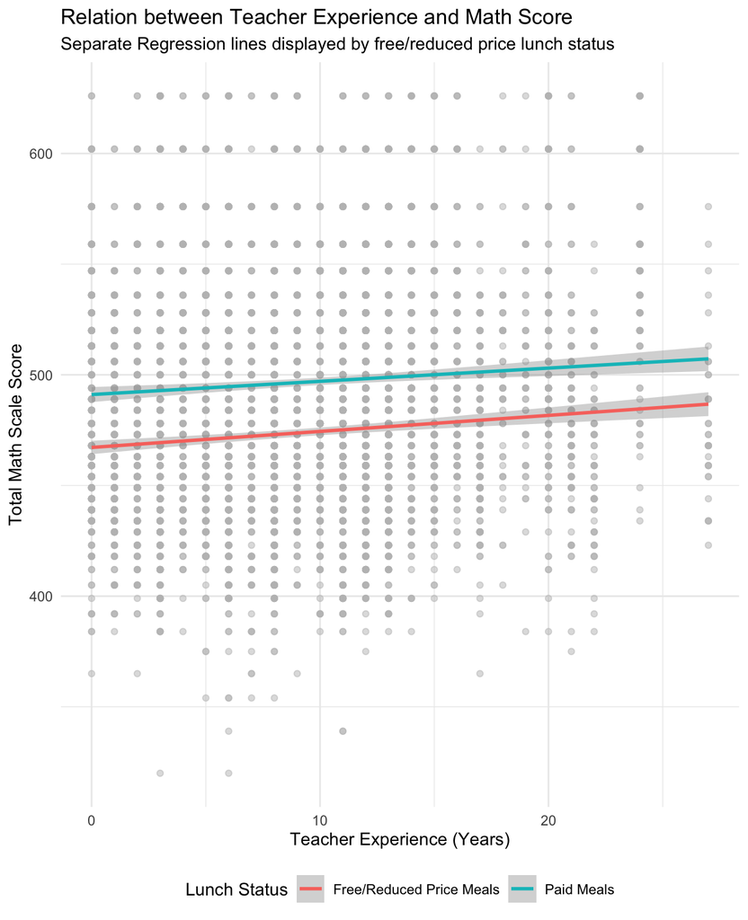

The above graph titled *Relation between Teacher Experience and Math Scores* displays how students with free/reduced meals, on average, perform **lower** on `total math scale score` as compared to students on paid meals. Teacher experience did slightly increase scores for both groups; however, students with paid meals consistently outperformed students with free/reduced meals, on average. There is **no overlap** between the two groups showing no interaction between the variables.

This is r-markdown document has (VanDerHeyden et al., 2018) as a reference.

This is r-markdown document has (Polikoff, 2010) as a reference.

This is r-markdown document has Naumann et al.’s article (2019) as a reference.

This is r-markdown document has Stockard et al.’s article (2018) as a reference.

# References

Naumann, A., Rieser, S., Musow, S., Hochweber, J., & Hartig, J. (2019). Sensitivity of test items to teaching quality. *Learning and Instruction*, *60*, 41–53. https://doi.org/10.1016/j.learninstruc.2018.11.002

Polikoff, M. S. (2010). Instructional sensitivity as a psychometric property of assessments: Winter, 2010. *Educational Measurement: Issues and Practice*, *29*(4), 3–14. https://doi.org/10.1111/j.1745-3992.2010.00189.x

Stockard, J., Wood, T. W., Coughlin, C., & Rasplica Khoury, C. (2018). The effectiveness of direct instruction curricula: A meta-analysis of a half century of research. *Review of Educational Research*, *88*(4), 479–507. https://doi.org/10.3102/0034654317751919

VanDerHeyden, A. M., Burns, M. K., & Bonifay, W. (2018). Is more screening better? The relationship between frequent screening, accurate decisions, and reading proficiency. *School Psychology Review*, *47*(1), 62–82. https://doi.org/10.17105/SPR-2017-0017.V47-1